# hw2

## Homework 2

1) A little introductory brain teaser. Which is more probable when rolling 2 six-sided dice: rolling snake eyes (two ones) or rolling sevens (dice sum to seven)? What is the ratio of the probabilities?

2) Following what we did in class show how to use the convolution operator to determine the probability of the sum of 2 six sided dice. Do both analytically (math & counting) and numerically (computer program). Beware the implicit definition of the values (x-axis on histogram).

3) Calculate the mean and the variance of the distribution in problem 2. Hint: this is surprisingly tricky, make sure your result makes sense.

4) Repeat 2, and graph the average of 10 dice. Is this is a Gaussian distribution? Explain in depth.

5) Show that the sum and average of an initially Gaussian distribution is also a Guassian (can be analytic or numerical). How does the standard deviation of the resulting sum or average Guassian change? This is a hugely important result. Explore what this means for integrating a signal over time.

#### Q1

A little introductory brain teaser. Which is more probable when rolling 2 six-sided dice: rolling snake eyes (two ones) or rolling sevens (dice sum to seven)? What is the ratio of the probabilities?

it is an 'and' question for rolling 2 ones. Hence, p(1,1) = 1/6 * 1/6 = 1/36 for rolling sevens, it is also an 'and' question, since that the first one could be every side but the second must be certain one that matches the other one to sum to 7. Hence, p(sum 7) = 1 * 1/6 = 1/6 Therefore, the ratio would be P(snake eyes)/P(sevens) = 1/6. In other words, Rolling a sum of seven is more probable here that is 6 times more probability than rolling snake eyes.

#### Q2

Following what we did in class show how to use the convolution operator to determine the probability of the sum of 2 six sided dice. Do both analytically (math & counting) and numerically (computer program). Beware the implicit definition of the values (x-axis on histogram).

the convolution operator is P_A+B(x) = P_A(x) * P_B(x) Hence, for x=2, P = 1/6 * 1/6=1/36; for x = 3, P = 2/6 * 1/6 = 2/36; for x = 4, P = 3/6 * 1/6....Until it reaches 7, P will be max. Then the probability will decrease.

```python
import numpy as np
import matplotlib
import matplotlib.pyplot as plt
import scipy
from scipy import stats
```

```python
dice = [1/6,1/6,1/6,1/6,1/6,1/6]
p_con= np.convolve(dice,dice,"full")
p_con
```

```
array([0.02777778, 0.05555556, 0.08333333, 0.11111111, 0.13888889,
       0.16666667, 0.13888889, 0.11111111, 0.08333333, 0.05555556,
       0.02777778])
```

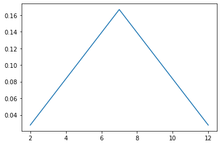

```python
x = np.linspace(2,12,11)
plt.plot(x,p_con)
```

As we can see from the plot above, the sum of two dice has the max probability when the sum is 7 which matches our expectation when we are doing the math & counting.

#### Q3

Calculate the mean and the variance of the distribution in problem 2. Hint: this is surprisingly tricky, make sure your result makes sense.

```python
p_mean = np.mean(p)
p_std = (np.std(p))**2
print(p_mean,p_std)
```

```
0.09090909090909091 0.0019768390980512193
```

#### Q4

Repeat 2, and graph the average of 10 dice. Is this is a Gaussian distribution? Explain in depth.

```python
np.convolve(dice,dice,"full")
```

```
array([0.02777778, 0.05555556, 0.08333333, 0.11111111, 0.13888889,
       0.16666667, 0.13888889, 0.11111111, 0.08333333, 0.05555556,
       0.02777778])
```

```python
p = []
p = np.convolve(dice,dice,"full")
for _ in range(8):
    p = np.convolve(p,dice, 'full')
len(p)
```

```
51
```

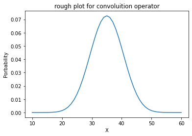

```python
x = np.linspace(10,60,51)
plt.plot(x,p)
plt.title('rough plot for convoluition operator')
plt.ylabel('Porbability')
plt.xlabel('X')
```

As we can see from the plot, it is much like a Guassian distribution comparing with two dice graph. It is making sense because according to central limit theory, most distributions, when averaged over enough trials, will converge to a Gaussian pdf.

#### Q5

Show that the sum and average of an initially Gaussian distribution is also a Guassian (can be analytic or numerical). How does the standard deviation of the resulting sum or average Guassian change? This is a hugely important result. Explore what this means for integrating a signal over time.

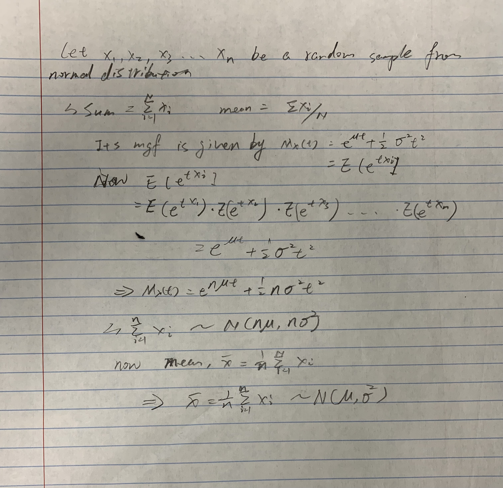

```python
from IPython.display import Image
Image("hw2_Q5.png")
```

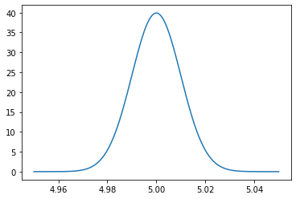

```python
#guassian distribution
x = np.linspace(4.95,5.05,1000)
norm_data = stats.norm.pdf(x,loc = 5., scale = 0.01)
plt.plot(x,norm_data)
```

```python
std_1 = np.std(norm_data)
std_1
```

```
13.491208562148767
```

```python
#10 average of the guassian distribution
p_norm = []
p_norm = np.convolve(norm_data,norm_data,"full")
for _ in range(8):
    p_norm = np.convolve(p_norm,norm_data, 'full')
len(p_norm)
```

```
9991
```

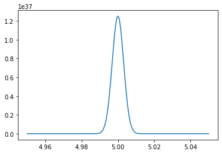

```python
xl = np.linspace(4.95,5.05,9991)
plt.plot(xl,p_norm)
```

```python
std_10 = np.std(p_norm)
std_10
```

```
2.789002696613352e+36
```

```python
p_norm = []
p_norm = np.convolve(norm_data,norm_data,"full")
for _ in range(15):
    p_norm = np.convolve(p_norm,norm_data, 'full')
len(p_norm)
```

```
16984
```

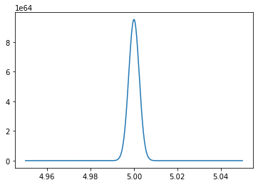

```python
xl = np.linspace(4.95,5.05,16984)
plt.plot(xl,p_norm)
```

```python
std_17 = np.std(p_norm)
std_17
```

```
1.8874396008502677e+64
```